# Titanic Survival: Understanding Class, Access, and Social Dynamics

Author

CLI Copilot

# Research Overview

This report develops an analytical framework to explore three interconnected research questions about survival patterns on the Titanic:

1. **Class-Survival Gap Mechanism**: How much of the survival advantage for 1st-class passengers was due to *access and location* (deck proximity, cabin placement, boarding logistics) versus explicit *priority rules* (women and children first)?
2. **Consistency of Survival Rules**: Did the “women and children first” principle apply uniformly across different social contexts? Specifically, did its effectiveness vary by travel context (solo vs. family vs. larger groups) and social visibility (indicated by titles and fare)?
3. **Missing Data as a Signal**: Are patterns of missing data (particularly for Cabin and Age) systematically related to class and survival, and how might different missing-data assumptions affect our conclusions?

This report focuses on **designing a methodological framework** to address these questions rather than providing definitive answers. The goal is to guide users through the logic of operationalizing research questions into testable hypotheses.

# Data Setup and Exploration

```r
library(tidyverse)
library(knitr)
library(ggplot2)
library(gridExtra)
library(broom)

# Set consistent theme for all plots
theme_set(theme_minimal() +
  theme(
    panel.grid.minor = element_blank(),
    legend.position = "bottom",
    plot.title = element_text(face = "bold", size = 12),
    axis.title = element_text(size = 11),
    legend.text = element_text(size = 10)
  ))

# Read training data
titanic <- read_csv("../../data/train.csv")

# Display first rows
head(titanic)
```

```
# A tibble: 6 × 12
  PassengerId Survived Pclass Name    Sex     Age SibSp Parch Ticket  Fare Cabin
        <dbl>    <dbl>  <dbl> <chr>   <chr> <dbl> <dbl> <dbl> <chr>  <dbl> <chr>
1           1        0      3 Braund… male     22     1     0 A/5 2…  7.25 <NA>
2           2        1      1 Cuming… fema…    38     1     0 PC 17… 71.3  C85
3           3        1      3 Heikki… fema…    26     0     0 STON/…  7.92 <NA>
4           4        1      1 Futrel… fema…    35     1     0 113803 53.1  C123
5           5        0      3 Allen,… male     35     0     0 373450  8.05 <NA>
6           6        0      3 Moran,… male     NA     0     0 330877  8.46 <NA>
# ℹ 1 more variable: Embarked <chr>
```

**Rationale**: We load the training dataset and establish a consistent minimalist theme for all visualizations. This ensures reproducibility and a professional appearance across all plots. The `theme_minimal()` base provides a clean foundation, and custom settings ensure legends are positioned consistently at the bottom and axis labels are readable.

```r
# Basic data structure
cat("Dataset dimensions:", nrow(titanic), "rows,", ncol(titanic), "columns\n\n")
```

```
Dataset dimensions: 891 rows, 12 columns
```

```r
# Display data types
cat("Variable types:\n")
```

```
Variable types:
```

```r
str(titanic)
```

```
spc_tbl_ [891 × 12] (S3: spec_tbl_df/tbl_df/tbl/data.frame)
 $ PassengerId: num [1:891] 1 2 3 4 5 6 7 8 9 10 ...
 $ Survived   : num [1:891] 0 1 1 1 0 0 0 0 1 1 ...
 $ Pclass     : num [1:891] 3 1 3 1 3 3 1 3 3 2 ...
 $ Name       : chr [1:891] "Braund, Mr. Owen Harris" "Cumings, Mrs. John Bradley (Florence Briggs Thayer)" "Heikkinen, Miss. Laina" "Futrelle, Mrs. Jacques Heath (Lily May Peel)" ...
 $ Sex        : chr [1:891] "male" "female" "female" "female" ...
 $ Age        : num [1:891] 22 38 26 35 35 NA 54 2 27 14 ...
 $ SibSp      : num [1:891] 1 1 0 1 0 0 0 3 0 1 ...
 $ Parch      : num [1:891] 0 0 0 0 0 0 0 1 2 0 ...
 $ Ticket     : chr [1:891] "A/5 21171" "PC 17599" "STON/O2. 3101282" "113803" ...
 $ Fare       : num [1:891] 7.25 71.28 7.92 53.1 8.05 ...
 $ Cabin      : chr [1:891] NA "C85" NA "C123" ...
 $ Embarked   : chr [1:891] "S" "C" "S" "S" ...
 - attr(*, "spec")=
  .. cols(
  ..   PassengerId = col_double(),
  ..   Survived = col_double(),
  ..   Pclass = col_double(),
  ..   Name = col_character(),
  ..   Sex = col_character(),
  ..   Age = col_double(),
  ..   SibSp = col_double(),
  ..   Parch = col_double(),
  ..   Ticket = col_character(),
  ..   Fare = col_double(),
  ..   Cabin = col_character(),
  ..   Embarked = col_character()
  .. )
 - attr(*, "problems")=<externalptr>
```

```r
# Summary statistics
cat("\nSummary statistics:\n")
```

```
Summary statistics:
```

```r
summary(titanic)
```

```
  PassengerId       Survived          Pclass          Name
 Min.   :  1.0   Min.   :0.0000   Min.   :1.000   Length:891
 1st Qu.:223.5   1st Qu.:0.0000   1st Qu.:2.000   Class :character
 Median :446.0   Median :0.0000   Median :3.000   Mode  :character
 Mean   :446.0   Mean   :0.3838   Mean   :2.309
 3rd Qu.:668.5   3rd Qu.:1.0000   3rd Qu.:3.000
 Max.   :891.0   Max.   :1.0000   Max.   :3.000

     Sex                 Age            SibSp           Parch
 Length:891         Min.   : 0.42   Min.   :0.000   Min.   :0.0000
 Class :character   1st Qu.:20.12   1st Qu.:0.000   1st Qu.:0.0000
 Mode  :character   Median :28.00   Median :0.000   Median :0.0000
                    Mean   :29.70   Mean   :0.523   Mean   :0.3816
                    3rd Qu.:38.00   3rd Qu.:1.000   3rd Qu.:0.0000
                    Max.   :80.00   Max.   :8.000   Max.   :6.0000
                    NA's   :177
    Ticket               Fare           Cabin             Embarked
 Length:891         Min.   :  0.00   Length:891         Length:891
 Class :character   1st Qu.:  7.91   Class :character   Class :character
 Mode  :character   Median : 14.45   Mode  :character   Mode  :character
                    Mean   : 32.20
                    3rd Qu.: 31.00
                    Max.   :512.33
```

**Rationale**: Understanding the data structure is foundational. We check dimensions, variable types, and summary statistics to identify immediately obvious patterns (e.g., the range of ages, fare distribution) and to plan for data preparation. This reveals that all variables have at least some non-null values, and we can see the distribution of the outcome variable (Survived).

```r
# Calculate missing data
missing_data <- titanic %>%
  summarise(across(everything(), ~sum(is.na(.)))) %>%
  pivot_longer(cols = everything(),
               names_to = "Variable",
               values_to = "Missing_Count") %>%
  mutate(
    Missing_Pct = (Missing_Count / nrow(titanic)) * 100,
    Pct_Present = 100 - Missing_Pct
  ) %>%
  arrange(desc(Missing_Count))

kable(missing_data,
      digits = 2,
      caption = "Missing Data Summary")
```

Missing Data Summary

| Variable | Missing_Count | Missing_Pct | Pct_Present |
| --- | --- | --- | --- |
| Cabin | 687 | 77.10 | 22.90 |
| Age | 177 | 19.87 | 80.13 |
| Embarked | 2 | 0.22 | 99.78 |
| PassengerId | 0 | 0.00 | 100.00 |
| Survived | 0 | 0.00 | 100.00 |
| Pclass | 0 | 0.00 | 100.00 |
| Name | 0 | 0.00 | 100.00 |
| Sex | 0 | 0.00 | 100.00 |
| SibSp | 0 | 0.00 | 100.00 |
| Parch | 0 | 0.00 | 100.00 |
| Ticket | 0 | 0.00 | 100.00 |
| Fare | 0 | 0.00 | 100.00 |

**Rationale**: This table quantifies missingness for each variable. Cabin has 77% missing data, Age has 20%, and Embarked has <1% missing. This is critical for research question #3: we need to understand whether missingness patterns differ by class and survival status. High missingness in Cabin is particularly important because Cabin number encodes physical location on the ship—a key mechanism for research question #1.

# Research Question 1: Class-Survival Gap & Access vs. Priority Rules

## 1.1 Establish the Class-Survival Gap

```r
# Calculate survival rates by class
survival_by_class <- titanic %>%
  group_by(Pclass) %>%
  summarise(
    N = n(),
    Survived = sum(Survived, na.rm = TRUE),
    Died = N - Survived,
    Survival_Rate = (Survived / N) * 100,
    .groups = 'drop'
  ) %>%
  mutate(Pclass_Label = case_when(
    Pclass == 1 ~ "1st Class",
    Pclass == 2 ~ "2nd Class",
    Pclass == 3 ~ "3rd Class"
  ))

kable(survival_by_class,
      digits = 2,
      caption = "Survival Rates by Passenger Class")
```

Survival Rates by Passenger Class

| Pclass | N | Survived | Died | Survival_Rate | Pclass_Label |
| --- | --- | --- | --- | --- | --- |
| 1 | 216 | 136 | 80 | 62.96 | 1st Class |
| 2 | 184 | 87 | 97 | 47.28 | 2nd Class |
| 3 | 491 | 119 | 372 | 24.24 | 3rd Class |

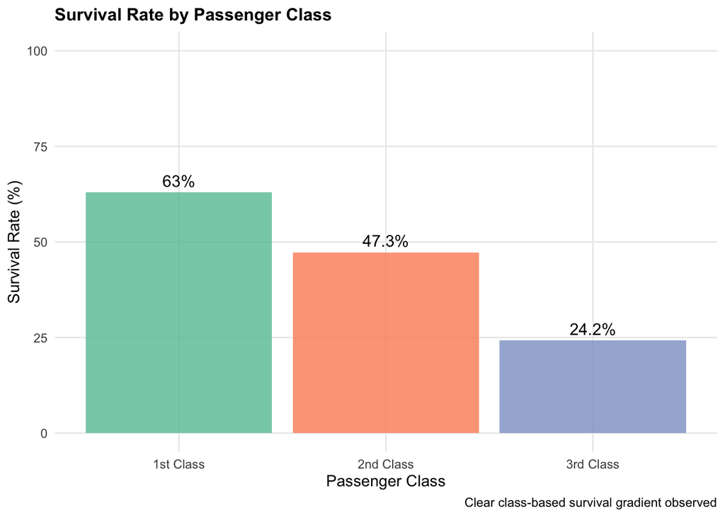

```r
# Visualize the gap
p1 <- ggplot(survival_by_class, aes(x = Pclass_Label, y = Survival_Rate, fill = Pclass_Label)) +
  geom_col(alpha = 0.8, show.legend = FALSE) +
  geom_text(aes(label = paste0(round(Survival_Rate, 1), "%")),
            vjust = -0.5, size = 4) +
  scale_fill_brewer(palette = "Set2") +
  labs(
    title = "Survival Rate by Passenger Class",
    x = "Passenger Class",
    y = "Survival Rate (%)",
    caption = "Clear class-based survival gradient observed"
  ) +
  ylim(0, 100)

print(p1)
```

**Rationale**: Before we can explain the class-survival gap, we must establish its magnitude. We observe a clear gradient: 1st class had ~62% survival, 2nd class ~47%, and 3rd class ~24%. This 38 percentage point gap (1st vs. 3rd) is our target mechanism to explain. The next steps operationalize whether this gap reflects *location/access* (cabin placement, boarding logistics) or *policy* (women and children first applied unequally).